# Case Illustration: Econometric Analysis

Understanding Policies (10700193-90)

Yue Hu

Tsinghua University

## Overview

- WHAT & WHY
  - An analysis on *how many* data points?
  - Why *not* experiments?
  - What do we look for with LNA?
- HOW

[figure not shown]

# What & Why

## What’s LNA

In lieu of “quantitative”…

Large-N: Number of **observations**—not participants, but trials/units

**How large? 10, 100, 1000, 10000?**

- > We don’t know……
- > It depends……
- > The larger, the better!

To know how large, you have to know why using this method…

## Why Not Experiments?

**Experiment is powerful!**

- Excluding confounders
- Clear outcomes
- Clear causal chain

**But**

- Difficult to conduct
- Difficult to represent
- No “cool” methods

Alternative: Quasi-experiment<sup>1</sup>

A.k.a., pseudo-random assignment

[^1]: *Collins Thesaurus*: Quasi- = pseudo-, apparent, seeming, semi-, so-called, would-be.

## Why Must N Be Large?

- Sufficient variance to fake the control-treatment structure
- Sufficient amount to represent the population

**Statistical foundation**

- Law of Large Numbers
- Central Limit Theorem

## Representation

*Law of Large Numbers*(LLN)

As the number of experiments (sample) increases, the ratio of outcomes will converge to the theoretical (population) average.

- → A rule of thumb: 100

*Central Limit Theorem*(CLT)

The sampling distribution of the sample means approaches a normal distribution as the sample size gets larger.

- → A rule of thumb: 1000 *(Where does this number come from? We’ll talk about that soon)*

## You gonna feel it

My highly-educated fellows, let’s play a happy-happy kid game!

And we are going outside! 😈

1. Toss a fair, single die
   - Odds: One step to the ←
   - Evens: One step to the →
2. Toss six times
3. Going forward

## Replicate the “magic”

[video not shown]

## Why Does CLT Require Over 1,000?

[figure not shown]

**The larger the better?**

$$\text{Margin of Error (M.E.)} = Z \times \frac{S}{\sqrt n}.$$

| Sample Size (n) | Margin of Error (M.E.) |
| --- | --- |
| 200 | 7.1% |
| 1000 | 3.2% |
| 2000 | 2.2% |
| 4000 | 1.6% |

*Now you know how large is large! Good for you 👍🎉*

## LNA for Public Policy

> 任何政策都建立在对事物差异性的分析和把握之上，**没有差异性就没有政策**。我国社会差异性特征明显，反映在地域、城乡、民族、人群等多个层面。我们的决策部署有综合性的，也有专项性的……这些都需要充分熟悉情况、深入分析论证、科学把握尺度。要坚持科学决策、民主决策、依法决策，对情况进行深入分析 (习近平 2019, 118–19)。

# How

## Univariate Analysis

[figure not shown]

| Student_ID | Courses |
| --- | --- |
| 2025097963 | 9 |
| 2025091648 | 9 |
| 2025097782 | 12 |
| 2025093288 | 10 |
| 2025093709 | 8 |
| 2025091864 | 10 |
| 2025094798 | 15 |

## How to Describe a Variable

Given the courses students took: (9, 9, 12, 10, 8, 10, 15)

- Mean: $\frac{9 + 9 + 12 + 10 + 8 + 10 + 15}{7} \approx 10.$
- Median: 8, 9, 9, 10, 10, 12, 15
- Mode: 8, 9, 9, 10, 10, 12, 15

*Which one is **the best**?*

[figure not shown]

How about this

## Levels of Descriptive Statistics

- Number
- Statistics
- Plot

Unique

Missing Pct.

Mean

SD

Min

Median

Max

Histogram

mpg

25

0

20.1

6.0

10.4

19.2

33.9

[figure not shown]

disp

27

0

230.7

123.9

71.1

196.3

472.0

[figure not shown]

hp

22

0

146.7

68.6

52.0

123.0

335.0

[figure not shown]

drat

22

0

3.6

0.5

2.8

3.7

4.9

[figure not shown]

wt

29

0

3.2

1.0

1.5

3.3

5.4

[figure not shown]

qsec

30

0

17.8

1.8

14.5

17.7

22.9

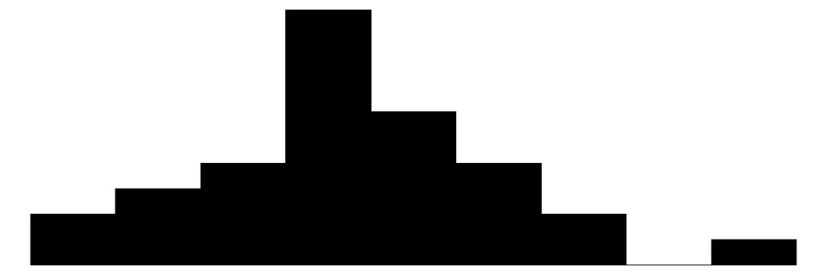

N

%

cyl

4

11

34.4

6

7

21.9

8

14

43.8

vs

FALSE

18

56.2

TRUE

14

43.8

gear

3

15

46.9

4

12

37.5

5

5

15.6

## Bivariate Analysis

[figure not shown]

Weight of a car and how long it can run

## Not Always Reliable

[figure not shown]

How about this data then?

## Multivariable Analysis

[figure not shown]

## Multivariable Analysis: Not a Panacea

[video not shown]

## Present Your Model Efficiently

[figure not shown]

## Take-Home Points

- What: “Quantitative” analysis
  - How large is large?
    - LLN: 100
    - CLT: 1000
- Why
  - Why Not experiment?
  - What do we look for from the LNA?
    - Average and distribution
- How
  - Univariate
  - Bivariate
  - Multivariate

*Bonus: If you wanna know more*

“治理技术专题：政治数据分析” (70700173) 😋

## Reference

Pizzi, Elise, and Yue Hu. 2022. “Does Governmental Policy Shape Migration Decisions? The Case of China’s Hukou System.” *Modern China* (Thousand Oaks) 48 (5): 1050–79. https://doi.org/10.1177/00977004221087426.

习近平. 2019. *论坚持党对一切工作的领导*. 中央文献出版社. https://books.google.com?id=yvt0zQEACAAJ.

胡悦, and 朱萌. 2022. “以语塑心与国民治理：外语习得对政治认知能力的塑造机制研究.” *治理研究* 38 (04): 51–65+125. https://doi.org/10.15944/j.cnki.33-1010/d.2022.04.007.

# Bonus: Policy Analysis with LNA

## Example 1: Hukou Policy and Migration Decisions? (Pizzi and Hu 2022)

**Research Question**

Does governmental hukou (户口) policy shape migrants’ destination choices in China?

- Cities set their own rules: how hard to *acquire* local hukou, and what *benefits* it confers
- Millions migrate despite strict policies — so what actually matters?

[figure not shown]

**Why this is a large-N problem**

- Hukou policy varies across hundreds of cities
- Individual migration choices are noisy — only patterns across thousands of cases reveal policy effects
- Need enough variation to separate hukou effects from economic ones

## Theories & hypotheses

**H₁: Barriers**

Strict hukou acquisition rules deter migrants from choosing that city

- Harder to get hukou → city less appealing
- Migrants actively avoid locked cities

**H₂: Benefits**

People prefer destinations where they can access public services and welfare

- H₂.₁: Cities where one *can get* local hukou are more attractive
- H₂.₂: Cities where services are accessible *regardless* of hukou status are even more attractive

**Note**

## Data: Two Sources, One Theory

**LESS 2018** *(survey experiment)*

- N = 1,100; 50% migrants, 50% non-migrants
- Online, quota-sampled (gender × education)
- Covers 31 provinces
- Key feature: embedded experiment — randomly shows respondents different hukou scenarios

**CLDS 2016** *(national representative survey)*

- N = 21,086 respondents
- Multi-stage stratified probability sample
- 145 cities across 29 provinces
- Checks generalizability of experimental results

## Variables and Analytical Strategy

**Key Variables**

| Variable | Measurement |
| --- | --- |
| OV (experiment) | Destination preference (1–5 Likert) |
| OV (survey) | Intent to stay long-term (1–5) |
| OV (survey) | Desire to acquire local hukou (1–5) |
| Treatment | easier hukou *vs.* education w/o hukou |
| EV (observed) | City hukou strictness (0–4) |

Controls: Age, gender, education, job type, income satisfaction

**Methods — from bivariate to multivariate**

- **Ordered logit** — appropriate for ordinal DV *(e.g., “how likely to stay: 1–5”)*
- **Kolmogorov-Smirnov test** — compare full distributions between experiment groups
- **Average marginal effects** — interpret conditional effects across city tiers

## Findings: Hukou as a Barrier?

[figure not shown]

Known

[figure not shown]

Careness

## Findings: Hukou as a Benefit?

[figure not shown]

## Example 2: English-Learning Policy and Political Minds? (胡悦 and 朱萌 2022)

[figure not shown]

**Why this is a large-N problem**

- Language effects on political cognition are subtle and cumulative — only detectable across thousands of respondents
- Need enough variation in English proficiency to separate language effects from education, income, and other confounders

**Research Question**

Does English proficiency shape Chinese citizens’ political cognitive capabilities?

- China has 400+ million English learners — a product of 40 years of mandatory education
- But does this language learning change *how people think about politics*?

## The Language Policy Field Model

**Core idea**

Language effects are policy-conditioned: the same language produces different political effects in different policy environments

**Four hypothesized mechanisms**

| Mechanism | Path | Prediction |
| --- | --- | --- |
| H₁ Information | English → internet use | ↑ internal & external efficacy |
| H₂ Values | English → Western values | ↑ internal, ↓ external efficacy |
| H₃ Self-evaluation | English → self-confidence | ↑ internal efficacy |
| H₄ Competition | Relative English advantage | ↑ internal & external efficacy |

## Data

**CGSS 2010**

- Chinese General Social Survey (中国综合社会调查)
- Multi-stage stratified probability sample
- 31 provinces, 140 cities, 2,762 communities
- N ≈ 11,700 usable respondents
- Contains rare items on both English proficiency *and* political efficacy

## Operation

| Variable | Measurement |
| --- | --- |
| OV | Internal political efficacy (1–5) |
| OV | External political efficacy (1–5) |
| EV | English proficiency (self-rated listening + speaking, 1–5) |
| Mediator 1 | Internet use frequency (1–5) |
| Mediator 2 | Attitude toward free speech (1–5) |
| Mediator 3 | Self-rated social class (1–10) |
| Mediator 4 | Relative English advantage (Δ from city mean) |
| Controls | Education, Mandarin, income (log), age, gender, party membership, rural status, migrant status, ethnicity; provincial fixed effects |

## Findings: What Drives Political Capability?

[figure not shown]